# Perceived Diversity in the Comic Book Community

Emily Jennings-Dobbs

4/20/2020

*Data cleanup*

```r
#read in data
library(readxl)
df <- read_excel("C:\\\\Users\\\\emily\\\\OneDrive\\\\Desktop\\\\temp\\\\Perceived Diversity in the Comic Book Community (Responses).xlsx")


head(df)
```

```
## # A tibble: 6 x 30
##   Timestamp           gender   age education race  involvement_base
##   <dttm>              <chr>  <dbl> <chr>     <chr>            <dbl>
## 1 2020-03-27 15:22:06 Male      22 complete~ Hisp~                2
## 2 2020-03-27 15:22:49 Female    17 No schoo~ White                4
## 3 2020-03-27 15:23:34 Female    22 some col~ White                3
## 4 2020-03-27 15:28:47 Female    19 some col~ White                4
## 5 2020-03-27 15:29:29 Female    19 some col~ White                4
## 6 2020-03-27 15:31:07 Male      21 High sch~ White                3
## # ... with 24 more variables: readership <dbl>, comic_cons <dbl>,
## #   comic_talk <dbl>, comic_shops <dbl>, cosplay <dbl>,
## #   acceptance_personal <chr>, acceptance_men <dbl>,
## #   acceptance_women <dbl>, acceptance_LGBT <dbl>, acceptance_POC <dbl>,
## #   expected_age <chr>, expected_race <chr>, expected_gender <chr>,
## #   expected_education <chr>, shy_outgoing <dbl>, inside_outside <dbl>,
## #   logic_emotion <dbl>, alonetime_withothers <dbl>, responsibility <dbl>,
## #   playsafe_risks <dbl>, imagination <dbl>, apathetic_empathetic <dbl>,
## #   groupwork_individual <dbl>, self_discipline <dbl>
```

```r
#turn table into data frame
library(tidyverse)
df <- as.data.frame(df, stringsAsFactors = TRUE)

#remove timestamp
df <- df[,-1]
head(df)
```

```
##   gender age                education               race involvement_base
## 1   Male  22 completed college degree Hispanic or Latino                2
## 2 Female  17   No schooling completed              White                4
## 3 Female  22             some college              White                3
## 4 Female  19             some college              White                4
## 5 Female  19             some college              White                4
## 6   Male  21              High school              White                3
##   readership comic_cons comic_talk comic_shops cosplay acceptance_personal
## 1          2          2          2           1       1              Unsure
## 2          5          3          4           3       2                 Yes
## 3          3          3          4           4       3                 Yes
## 4          3          2          5           3       3              Unsure
## 5          3          2          5           3       3              Unsure
## 6          5          4          6           2       5                 Yes
##   acceptance_men acceptance_women acceptance_LGBT acceptance_POC
```

[output cut: 34 more lines]

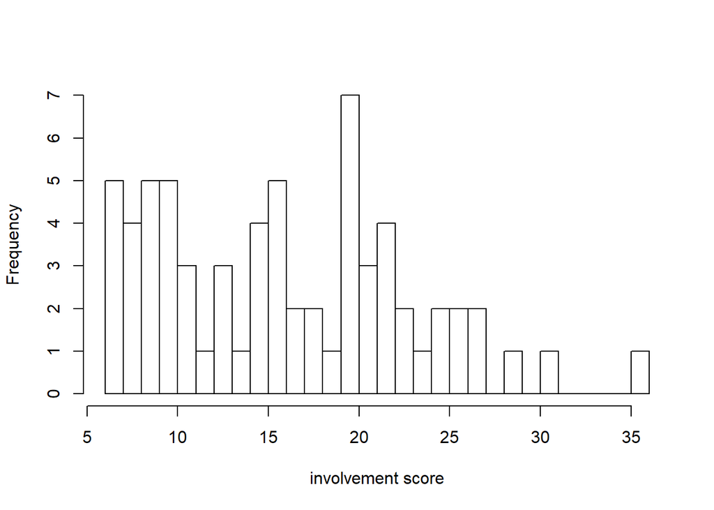

```r
#calculate involvement score
df <- df %>% mutate(involvement_sum = involvement_base + readership + comic_cons + comic_talk + comic_shops + cosplay)

hist(df$involvement_sum, breaks = 40, xlab = "involvement score", main = NULL)
```

A sum of all involvement scores is used as an overall score of involvement in the comic book community.

```r
#create dataframe without invalid expected age
alt_df <- df %>% filter(nchar(expected_age)<=2) %>% mutate(expected_age = as.numeric(expected_age))
head(alt_df)
```

```
##   gender age                education               race involvement_base
## 1   Male  22 completed college degree Hispanic or Latino                2
## 2 Female  22             some college              White                3
## 3 Female  19             some college              White                4
## 4 Female  19             some college              White                4
## 5   Male  21              High school              White                3
## 6 Female  20             some college              White                1
##   readership comic_cons comic_talk comic_shops cosplay acceptance_personal
## 1          2          2          2           1       1              Unsure
## 2          3          3          4           4       3                 Yes
## 3          3          2          5           3       3              Unsure
## 4          3          2          5           3       3              Unsure
## 5          5          4          6           2       5                 Yes
## 6          2          1          2           2       1              Unsure
##   acceptance_men acceptance_women acceptance_LGBT acceptance_POC
```

[output cut: 34 more lines]

```r
#remove excess factors
for(i in 1:51){
  if(alt_df[i, "gender"]!= "Female" && alt_df[i, "gender"]!= "Male"){
    alt_df[i, "gender"]="Other"
  }
}

for(i in 1:51){
  if(alt_df[i, "race"]!= "White" && alt_df[i, "race"]!= "Hispanic or Latino"  && alt_df[i, "race"]!= "Black or African American"){
    alt_df[i, "race"]="Other"
  }
}

for(i in 1:51){
  if(alt_df[i, "expected_race"]!= "White" && alt_df[i, "expected_race"]!= "Hispanic or Latino"  && alt_df[i, "expected_race"]!= "Black or African American"){
    alt_df[i, "expected_race"]="Other"
  }
}
```

*Graphs*

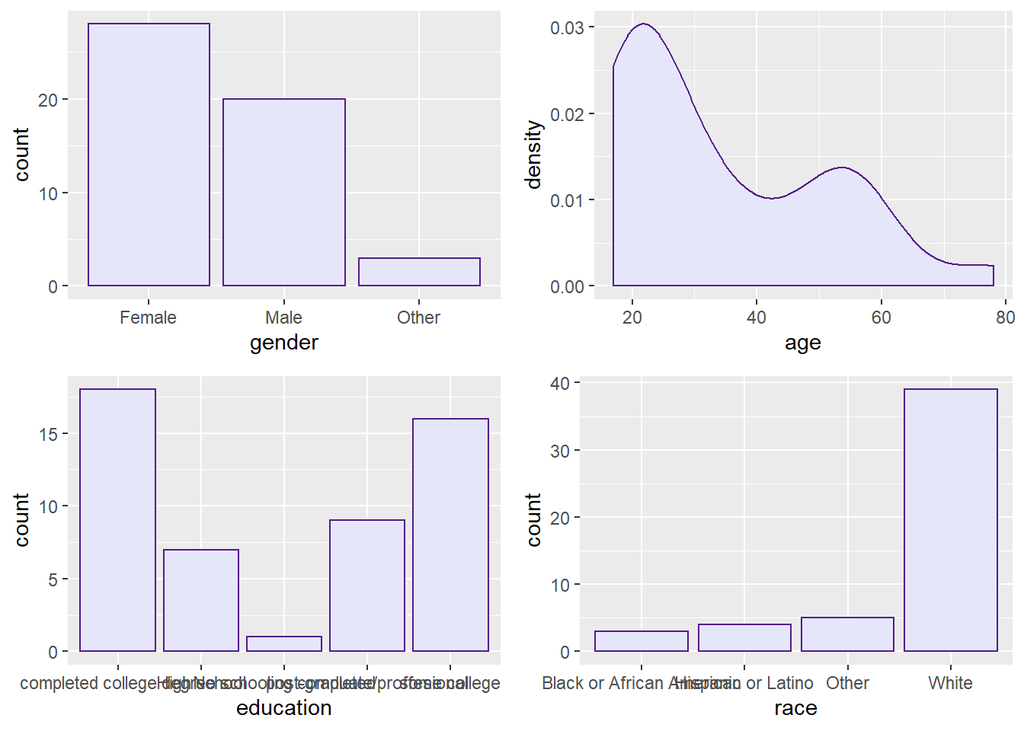

```r
df_factor <- alt_df %>%
  mutate_if(sapply(alt_df, is.character), as.factor)



library(cowplot)
my_plots <- lapply(names(df_factor), function(var_x){
  p <-
    ggplot(df_factor) +
    aes_string(var_x)

  if(is.numeric(df_factor[[var_x]])) {
    p <- p + geom_density(color="purple4", fill="lavender")

  } else {
    p <- p + geom_bar(color="purple4", fill="lavender")  + scale_fill_discrete(drop=TRUE)
  }
})

plot_grid(plotlist = my_plots[1:4])
```

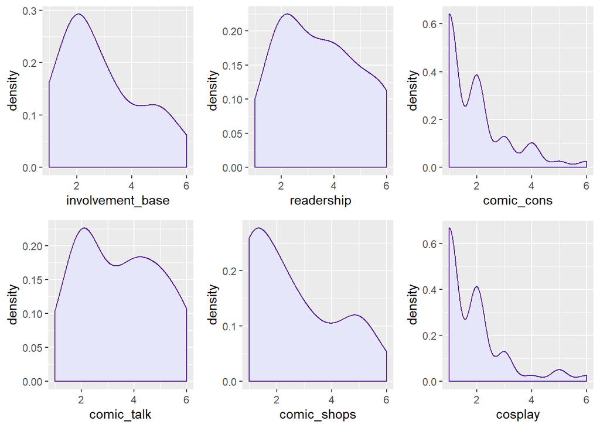

```r
plot_grid(plotlist = my_plots[5:10])
```

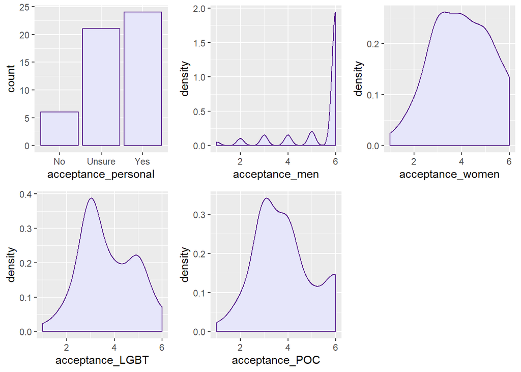

```r
plot_grid(plotlist = my_plots[11:15])
```

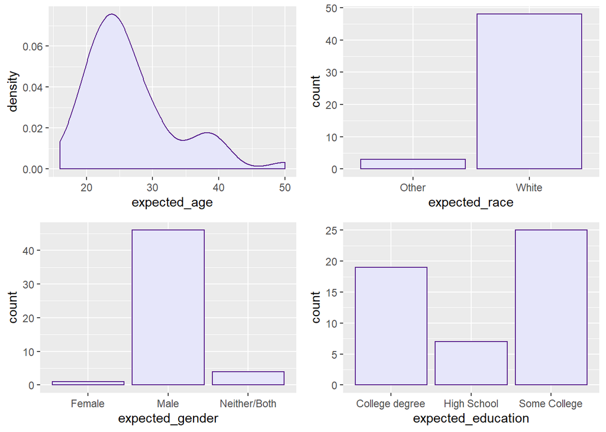

```r
plot_grid(plotlist = my_plots[16:19])
```

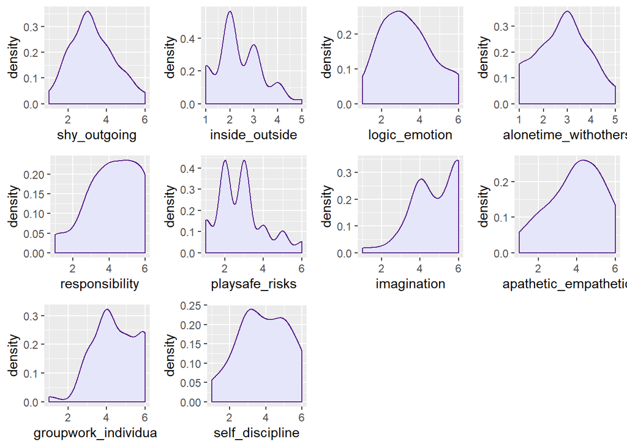

```r
plot_grid(plotlist = my_plots[20:29])
```

*Personality Variables*

```r
personality_df <- df %>% dplyr::select(shy_outgoing, inside_outside, logic_emotion, alonetime_withothers, responsibility, playsafe_risks, imagination, apathetic_empathetic, groupwork_individual, self_discipline)

p_values <- matrix(nrow = ncol(personality_df), ncol = 2)

row.names(p_values) <- colnames(personality_df)
colnames(p_values) <- c("p_value", "Decision")

for (i in 1:ncol(personality_df)) {
  y <- t.test(personality_df[,i], mu = 3.5)
  p_values[i,1] <- y$p.value

  if(p_values[i,1] >= .05){
    p_values[i,2] <- "fail to reject"
  }else{
    p_values[i,2] <- "reject"
  }
}

knitr::kable(as.data.frame(p_values), "markdown")
```

[output not shown]

```r
rm(p_values)
```

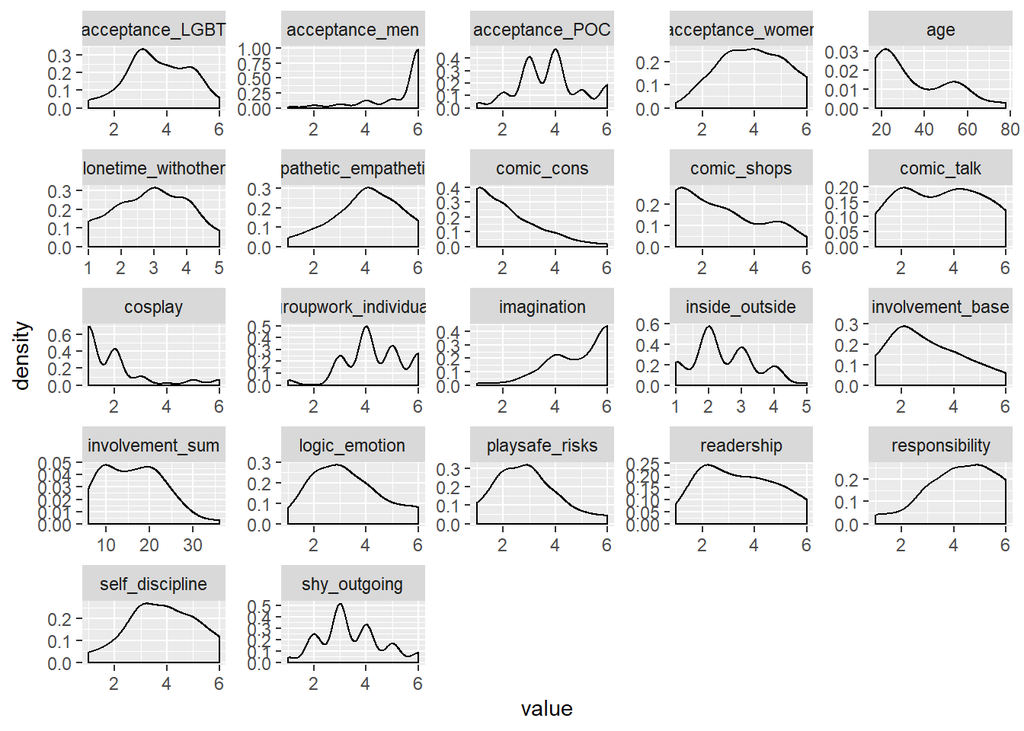

```r
library(ggplot2)
df %>%
  keep(is.numeric) %>%                     # Keep only numeric columns
  gather() %>%                             # Convert to key-value pairs
  ggplot(aes(value)) +                     # Plot the values
    facet_wrap(~ key, scales = "free") +   # In separate panels
    geom_density()                         # as density
```

*Expectation & Acceptance T-tests*

```r
#50.8% of people are women
table(df$expected_gender)
```

```
##
##       Female         Male Neither/Both
##            1           54           12
```

54/67 believed the average person in the comic book community was male

```r
binom.test(54,67,p = .492)
```

```
##
##  Exact binomial test
##
## data:  54 and 67
## number of successes = 54, number of trials = 67, p-value =
## 2.16e-07
## alternative hypothesis: true probability of success is not equal to 0.492
## 95 percent confidence interval:
##  0.6910883 0.8924405
## sample estimates:
## probability of success
##              0.8059701
```

An exact binomial test gives us a p-value of 2.16e-07 which is well below .05, so we reject the NULL hypothesis that people expect about half the population of the comic book community and instead believe men to make up between 69% to 89% of the population.

```r
table(df$expected_race)
```

```
##
##                    all races     Asian / Pacific Islander
##                            1                            2
## I think it's a blend of all.       Mostly white and Asian
##                            1                            1
##                        White
##                           62
```

According to cencus data 76.5% of the US population is white.

```r
binom.test(62,67,p = .765)
```

```
##
##  Exact binomial test
##
## data:  62 and 67
## number of successes = 62, number of trials = 67, p-value =
## 0.001254
## alternative hypothesis: true probability of success is not equal to 0.765
## 95 percent confidence interval:
##  0.8343738 0.9753253
## sample estimates:
## probability of success
##              0.9253731
```

62 out of 67 people think the average person in the comic community is white. This is significantly larger than the proportion of white people in the US.

*Correlational Study*

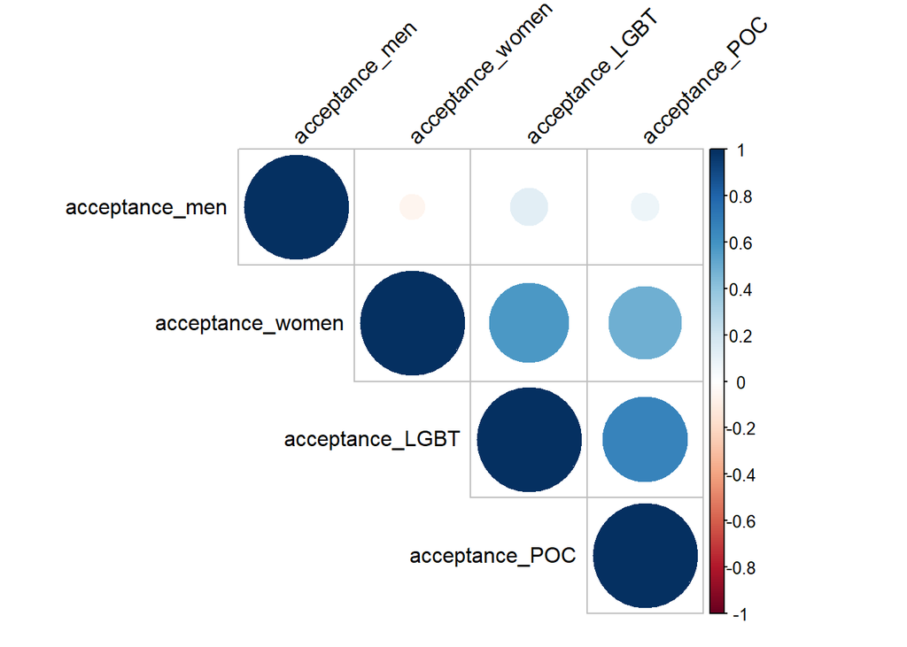

```r
personality_cor <- cor(df %>% dplyr::select(shy_outgoing, inside_outside, logic_emotion, alonetime_withothers, responsibility, playsafe_risks, imagination, apathetic_empathetic, groupwork_individual, self_discipline))



Acceptance_cor <- cor(df %>% dplyr::select(acceptance_men, acceptance_women, acceptance_LGBT, acceptance_POC))



library(corrplot)
#correlation plot of acceptance questions
corrplot(Acceptance_cor, type = "upper", order = "hclust",
         tl.col = "black", tl.srt = 45)
```

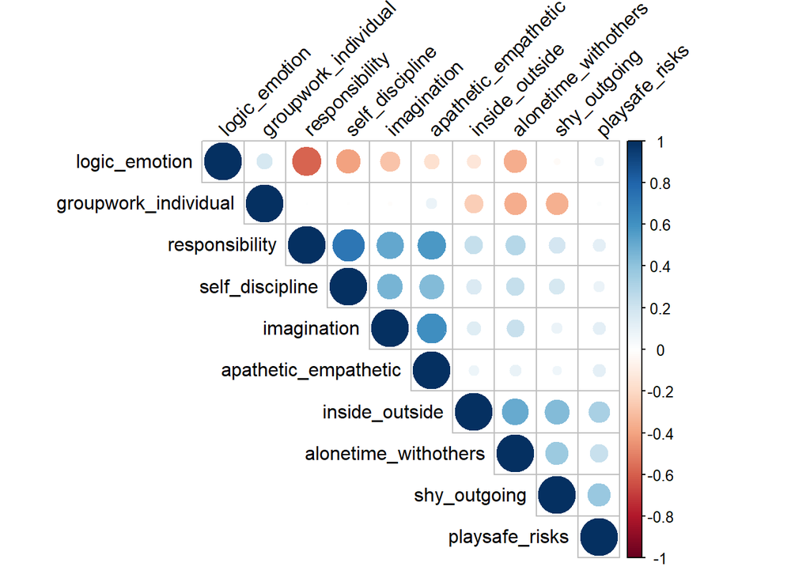

```r
#correlation plot of personality questions
corrplot(personality_cor, type = "upper", order = "hclust",
         tl.col = "black", tl.srt = 45)
```

```r
numeric_df <- df %>% keep(is.numeric)


p_values <- matrix(nrow = ncol(numeric_df), ncol = 3)

row.names(p_values) <- colnames(numeric_df)
colnames(p_values) <- c("p_value", "Decision", "correlation")

for (i in 1:ncol(numeric_df)) {
  y <- cor.test(numeric_df[,i] ,df$age, method = "pearson")

  p_values[i,1] <- y$p.value

  if(p_values[i,1] >= .05){
    p_values[i,2] <- "fail to reject"
  }else{
    p_values[i,2] <- "reject"
  }

  p_values[i,3] <- y$estimate
}

knitr::kable(as.data.frame(p_values), "markdown")
```

|  | p_value | Decision | correlation |
| --- | --- | --- | --- |
| age | 0 | reject | 1 |
| involvement_base | 0.564736141964001 | fail to reject | 0.0716048698337643 |
| readership | 0.985938048808307 | fail to reject | 0.00219452789030961 |
| comic_cons | 0.281283908746492 | fail to reject | -0.133552780650623 |
| comic_talk | 0.285978474848553 | fail to reject | -0.132268399282288 |
| comic_shops | 0.361262791997927 | fail to reject | -0.113308579562833 |
| cosplay | 0.226850732458603 | fail to reject | -0.149626100167845 |
| acceptance_men | 0.895324122217361 | fail to reject | -0.0163810804491988 |
| acceptance_women | 0.589942538523075 | fail to reject | -0.0670267303129312 |
| acceptance_LGBT | 0.38853027163622 | fail to reject | -0.107056459191553 |
| acceptance_POC | 0.385323334271409 | fail to reject | -0.107777784149333 |
| shy_outgoing | 0.388901245175323 | fail to reject | 0.10697324651905 |
| inside_outside | 0.0307706410807177 | reject | 0.264153628983857 |
| logic_emotion | 0.0769748703830903 | fail to reject | -0.217556630880652 |
| alonetime_withothers | 0.0662588781329044 | fail to reject | 0.225727109569913 |
| responsibility | 0.0128076115655008 | reject | 0.302617139613015 |
| playsafe_risks | 0.277473463134962 | fail to reject | 0.134605761310564 |
| imagination | 0.00588524880218801 | reject | 0.333070607537102 |
| apathetic_empathetic | 0.369006509606232 | fail to reject | 0.111504817988363 |
| groupwork_individual | 0.603583775327367 | fail to reject | 0.0645860933919328 |
| self_discipline | 0.0839023107883511 | fail to reject | 0.212746248842352 |
| involvement_sum | 0.453165651013223 | fail to reject | -0.0931993240141514 |

```r
t.test(df$acceptance_men, df$acceptance_women)
```

```
##
##  Welch Two Sample t-test
##
## data:  df$acceptance_men and df$acceptance_women
## t = 6.7581, df = 130.81, p-value = 4.177e-10
## alternative hypothesis: true difference in means is not equal to 0
## 95 percent confidence interval:
##  1.013408 1.852264
## sample estimates:
## mean of x mean of y
##  5.388060  3.955224
```

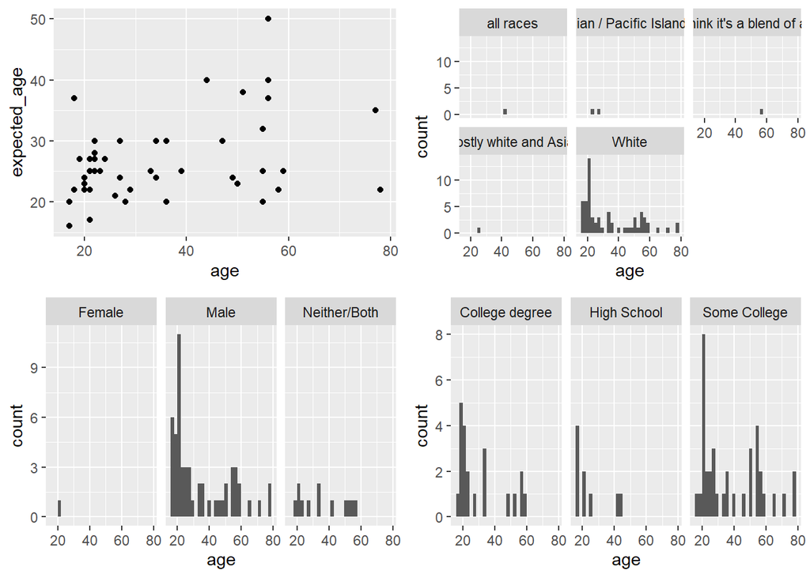

```r
#better plots
library(ggpubr)
#demographics vs expectation
  #age vs expectation (age, race, gender, education)
  aea <- ggplot(alt_df, aes(age, expected_age)) + geom_point()
  aer <- ggplot(df, aes(age)) + geom_histogram() + facet_wrap(~expected_race)
  aeg <- ggplot(df, aes(age)) + geom_histogram() + facet_wrap(~expected_gender)
  aee <- ggplot(df, aes(age)) + geom_histogram() + facet_wrap(~expected_education)
  ggarrange(aea, aer, aeg, aee)
```

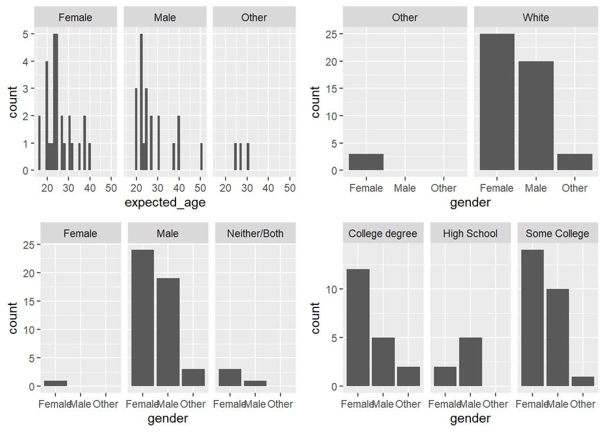

```r
  #gender vs expectation
  gea <- ggplot(alt_df, aes(x=expected_age)) + geom_histogram() + facet_wrap(~gender)
  ger <- ggplot(alt_df, aes(x = gender)) + geom_bar() + facet_wrap(~expected_race)
  geg <- ggplot(alt_df, aes(gender)) + geom_bar() +facet_wrap(~expected_gender)
  gee <- ggplot(alt_df, aes(gender)) + geom_bar() +facet_wrap(~expected_education)

  ggarrange(gea, ger, geg, gee)
```

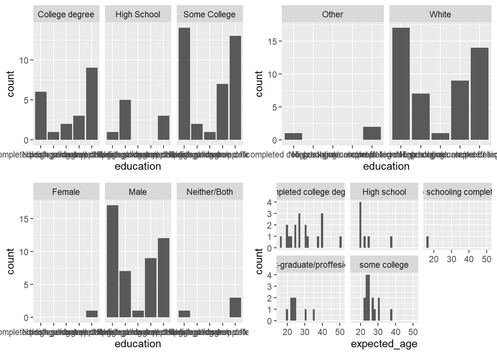

```r
  #education vs expectation
  eee <- ggplot(df, aes(education)) + geom_bar() +facet_wrap(~expected_education)
  eer <- ggplot(alt_df, aes(x = education)) + geom_bar() + facet_wrap(~expected_race)
  eeg <- ggplot(alt_df, aes(education)) + geom_bar() +facet_wrap(~expected_gender)
  eea <- ggplot(alt_df, aes(x=expected_age)) + geom_histogram() + facet_wrap(~education)

  ggarrange(eee, eer, eeg, eea)
```

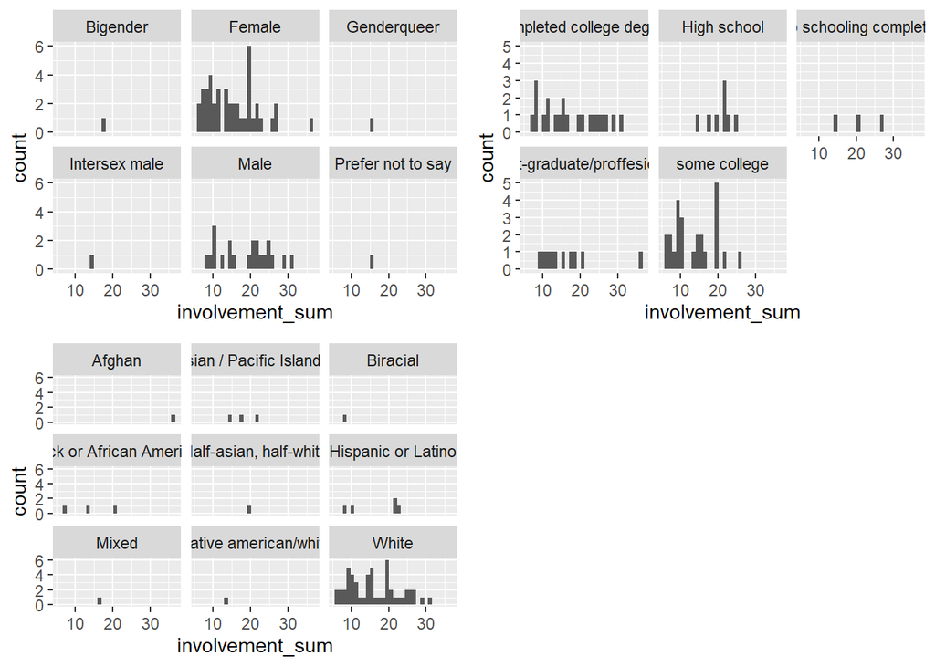

```r
#demographics vs Involvement

ig <- ggplot(df, aes(involvement_sum)) + geom_histogram() + facet_wrap(~gender)
ie <- ggplot(df, aes(involvement_sum)) + geom_histogram() + facet_wrap(~education)
ir <- ggplot(df, aes(involvement_sum)) + geom_histogram() + facet_wrap(~race)

ggarrange(ig, ie, ir)
```

```r
#median age is 38.2

t.test(alt_df$expected_age, mu = 38.2)
```

```
##
##  One Sample t-test
##
## data:  alt_df$expected_age
## t = -12.151, df = 50, p-value < 2.2e-16
## alternative hypothesis: true mean is not equal to 38.2
## 95 percent confidence interval:
##  24.64599 28.49127
## sample estimates:
## mean of x
##  26.56863
```

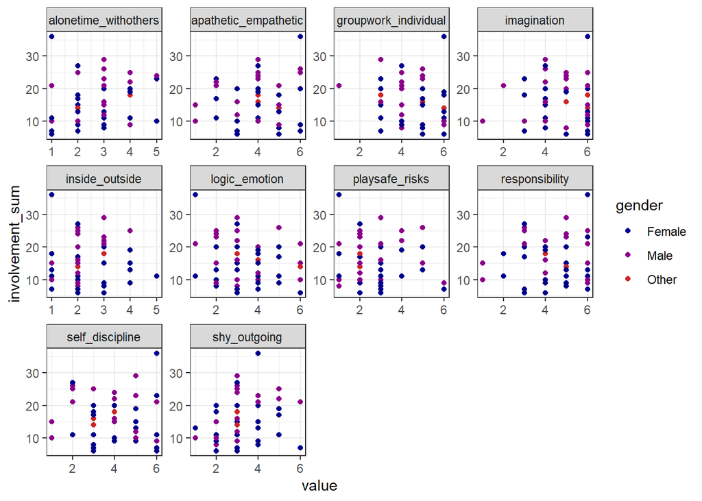

```r
alt_df %>%
  dplyr::select(gender, involvement_sum,shy_outgoing, inside_outside, logic_emotion, alonetime_withothers, responsibility, playsafe_risks, imagination, apathetic_empathetic, groupwork_individual, self_discipline ) %>%
  gather(-involvement_sum, -gender, key = "var", value = "value") %>%
  ggplot(aes(x = value, y = involvement_sum, color = gender)) +
    geom_point() +
    facet_wrap(~ var, scales = "free") +
    theme_bw() +
    scale_color_manual(values=c("blue4", "darkmagenta", "firebrick3"))
```

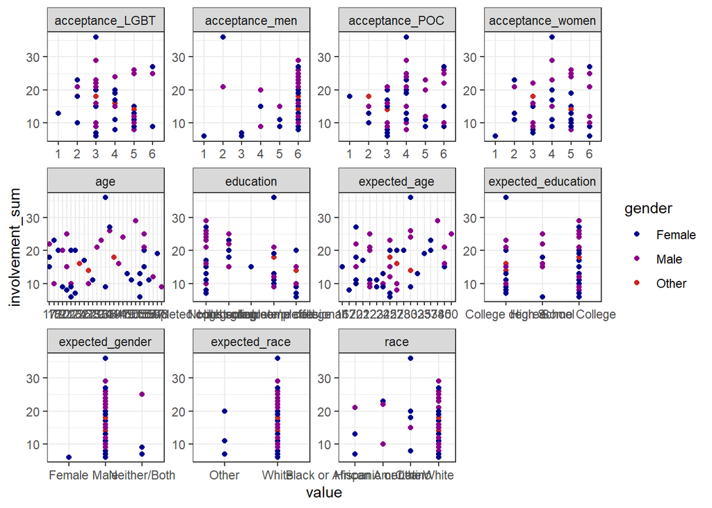

```r
alt_df %>%
  dplyr::select(gender, involvement_sum, age, education, race, acceptance_men, acceptance_women, acceptance_LGBT, acceptance_POC, expected_age, expected_race, expected_gender, expected_education  ) %>%
  gather(-involvement_sum, -gender, key = "var", value = "value") %>%
  ggplot(aes(x = value, y = involvement_sum, color = gender)) +
    geom_point() +
    facet_wrap(~ var, scales = "free") +
    theme_bw() +
    scale_color_manual(values=c("blue4", "darkmagenta", "firebrick3"))
```